# Udacity Self-Driving Car Engineer Nanodegree Program

## Vehicle Detection Project

The goals / steps of this project are the following:

- Perform a Histogram of Oriented Gradients (HOG) feature extraction on a labeled training set of images and train a classifier Linear SVM classifier
- Optionally, you can also apply a color transform and append binned color features, as well as histograms of color, to your HOG feature vector.
- Note: for those first two steps don't forget to normalize your features and randomize a selection for training and testing.
- Implement a sliding-window technique and use your trained classifier to search for vehicles in images.
- Run your pipeline on a video stream (start with the test_video.mp4 and later implement on full project_video.mp4) and create a heat map of recurring detections frame by frame to reject outliers and follow detected vehicles.
- Estimate a bounding box for vehicles detected.

### Import Packages

```python
from skimage.feature import hog
from sklearn.utils import shuffle
from sklearn.svm import LinearSVC
from sklearn.preprocessing import StandardScaler
# for scikit-learn >= 0.18 use:
from sklearn.model_selection import train_test_split
# from sklearn.cross_validation import train_test_split
from scipy.ndimage.measurements import label
# import matplotlib.image as mpimg
import matplotlib.pyplot as plt
from moviepy.editor import VideoFileClip
from IPython.display import HTML
import numpy as np
import pandas as pd
import pickle
import cv2
import glob
import time
import random

%matplotlib inline

print('>> Done!')
```

```
>> Done!
```

### Helper Functions

The following code cell includes some helper functions which has been used in the rest of implementation.

```python
def plot_sample_data(files, titles, v_plot_count=1, fig_size=(8, 8), _axis = 'off'):
    h_plot_count = len(files)//v_plot_count
    fig, axs = plt.subplots(v_plot_count, h_plot_count, figsize=fig_size)
    fig.subplots_adjust(hspace = .2, wspace=.001)
    axs = axs.ravel()
    for i in np.arange(len(files)):
        img = read_img(files[i])
        axs[i].axis(_axis)
        axs[i].set_title(titles[i], fontsize=10)
        axs[i].imshow(img)


def plot_sample_data_img(images, titles, v_plot_count=1, fig_size=(8, 8), _axis = 'off'):
    h_plot_count = len(images)//v_plot_count
    fig, axs = plt.subplots(v_plot_count, h_plot_count, figsize=fig_size)
    fig.subplots_adjust(hspace = .2, wspace=.001)
    axs = axs.ravel()
    for i, img in enumerate(images):
        axs[i].axis(_axis)
        axs[i].set_title(titles[i], fontsize=10)
        axs[i].imshow(img)


def read_img(file):
    img = cv2.imread(file)
    img = cv2.cvtColor(img,cv2.COLOR_BGR2RGB)
    return img


def convert_color(image, conv='RGB'):
    if color_space != 'RGB':
        if color_space == 'HSV':
            feature_image = cv2.cvtColor(image, cv2.COLOR_RGB2HSV)
        elif color_space == 'LUV':
            feature_image = cv2.cvtColor(image, cv2.COLOR_RGB2LUV)
        elif color_space == 'HLS':
            feature_image = cv2.cvtColor(image, cv2.COLOR_RGB2HLS)
        elif color_space == 'YUV':
            feature_image = cv2.cvtColor(image, cv2.COLOR_RGB2YUV)
        elif color_space == 'YCrCb':
            feature_image = cv2.cvtColor(image, cv2.COLOR_RGB2YCrCb)
    else: feature_image = np.copy(image)

    return feature_image


def draw_boxes(img, bboxes, color=(0, 0, 255), thick=6):
    # Make a copy of the image
    imcopy = np.copy(img)
    random_color = False
    # Iterate through the bounding boxes
    for bbox in bboxes:
        if color == 'random' or random_color:
            color = (np.random.randint(0,255), np.random.randint(0,255), np.random.randint(0,255))
            random_color = True
        # Draw a rectangle given bbox coordinates
        cv2.rectangle(imcopy, bbox[0], bbox[1], color, thick)
    # Return the image copy with boxes drawn
    return imcopy
```

### Training Data Set

All images are the same shape `(64x64x3)` and in `*.png` format.

```python
car_images = glob.glob('./data_set/vehicles/**/*.png')
noncar_images = glob.glob('./data_set/non-vehicles/**/*.png')

car_images = shuffle(car_images)
noncar_images = shuffle(noncar_images)

print('>> Number of "cars" images: ',len(car_images))
print('>> Number of "non-cars" images: ',len(noncar_images))
```

```
>> Number of "cars" images:  8792
>> Number of "non-cars" images:  8968
```

### Plot Some Random Data

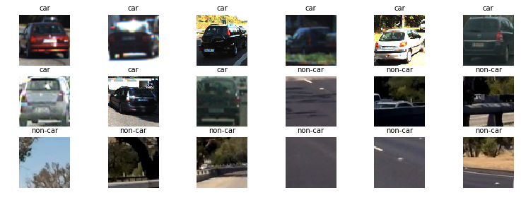

```python
n = 3
count = n*n
# car
sample_cars = shuffle(car_images, n_samples=count)
sample_cars_title = ['car']*count
# non-acar
sample_noncars = shuffle(noncar_images, n_samples=count)
sample_noncars_title = ['non-car']*count
# all
samples =np.concatenate((sample_cars, sample_noncars))
samples_title =np.concatenate((sample_cars_title, sample_noncars_title))
# plot
plot_sample_data(samples, samples_title, v_plot_count=n, fig_size=(count*1.5, n*1.5,))
```

### Convert Image to Histogram of Oriented Gradients (HOG)

```python
def get_hog_features(img, orient, pix_per_cell, cell_per_block,
                     vis=False, feature_vec=True):
    """
    A function to return HOG features and visualization
    """
    # Call with two outputs if vis==True
    if vis == True:
        features, hog_image = hog(img, orientations=orient,
                                  pixels_per_cell=(pix_per_cell, pix_per_cell),
                                  cells_per_block=(cell_per_block, cell_per_block),
                                  transform_sqrt=False,
                                  visualise=vis, feature_vector=feature_vec)
        return features, hog_image
    # Otherwise call with one output
    else:
        features = hog(img, orientations=orient,
                       pixels_per_cell=(pix_per_cell, pix_per_cell),
                       cells_per_block=(cell_per_block, cell_per_block),
                       transform_sqrt=False,
                       visualise=vis, feature_vector=feature_vec)
        return features
```

#### Calculate and Visualize HOG for One Sample Data

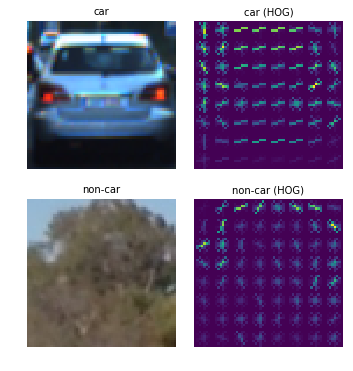

```python
# car sample
sample_car = shuffle(car_images, n_samples=1)[0]
img_car = read_img(sample_car)
_, img_car_hog = get_hog_features(img_car[:,:,2], 9, 8, 8, vis=True, feature_vec=True)
sample_cars_title = ['car', 'car (HOG)']
# non-car sample
sample_noncar = shuffle(noncar_images, n_samples=2)[0]
img_noncar = read_img(sample_noncar)
_, img_noncar_hog = get_hog_features(img_noncar[:,:,2], 9, 8, 8, vis=True, feature_vec=True)
sample_noncars_title = ['non-car', 'non-car (HOG)']
# all
samples= [img_car, img_car_hog, img_noncar, img_noncar_hog]
titles = np.concatenate((sample_cars_title, sample_noncars_title))
#plot
plot_sample_data_img(samples, titles, v_plot_count=2, fig_size=(6, 6))
```

### Extract HOG Features from an Array of Car and Non-Car Images

```python
def bin_spatial(img, size=(32, 32)):
    """
    A function to compute binned color features
    """
    # Use cv2.resize().ravel() to create the feature vector
    features = cv2.resize(img, size).ravel()
    # Return the feature vector
    return features


def color_hist(img, nbins=32, bins_range=(0, 256)):
    """
    - Define a function to compute color histogram features
    - NEED TO CHANGE bins_range if reading ".png" files with mpimg!
    """
    # Compute the histogram of the color channels separately
    channel1_hist = np.histogram(img[:,:,0], bins=nbins, range=bins_range)
    channel2_hist = np.histogram(img[:,:,1], bins=nbins, range=bins_range)
    channel3_hist = np.histogram(img[:,:,2], bins=nbins, range=bins_range)
    # Concatenate the histograms into a single feature vector
    hist_features = np.concatenate((channel1_hist[0], channel2_hist[0], channel3_hist[0]))
    # Return the individual histograms, bin_centers and feature vector
    return hist_features


def extract_features(imgs, color_space='RGB', spatial_size=(32, 32),
                        hist_bins=32, orient=9,
                        pix_per_cell=8, cell_per_block=2, hog_channel=0):
    """
    - A function to extract features from a list of images
    - Have this function call bin_spatial() and color_hist()
    """
    # Create a list to append feature vectors to
    features = []
    # Iterate through the list of images
    for file in imgs:
        file_features = []
        # Read in each one by one
        image = read_img(file)
        # apply color conversion if other than 'RGB'
        feature_image = convert_color(image, conv=color_space)


        # Call get_hog_features() with vis=False, feature_vec=True
        if hog_channel == 'ALL':
            hog_features = []
            for channel in range(feature_image.shape[2]):
                hog_features.append(get_hog_features(feature_image[:,:,channel],
                                    orient, pix_per_cell, cell_per_block,
                                    vis=False, feature_vec=True))
            hog_features = np.ravel(hog_features)
        else:
            hog_features = get_hog_features(feature_image[:,:,hog_channel], orient,
                        pix_per_cell, cell_per_block, vis=False, feature_vec=True)
        # Append the new feature vector to the features list
        file_features.append(hog_features)
        features.append(np.concatenate(file_features))
    # Return list of feature vectors
    return features
```

### Feature Extraction

Steps are as following:

- Extract the features for data set.
- Combine them
- Define the labels
- Shuffle and split

First, define some usefule parameters:

```python
colorspaces = {0:'YUV', 1:'RGB', 2:'HSV', 3:'LUV', 4:'HLS', 5:'YCrCb'}
hog_channels = {0:0, 1:1, 2:2, 3:'ALL'}
orients = [9, 11]

color_space = colorspaces[0]
hog_channel = hog_channels[3]
orient = orients[1]
pix_per_cell = 8
cell_per_block = 2
split_ratio = 0.2
```

Extract features from data set for:

> **The folloing code cell takes ~8min to run.**

```python
features = {'car': [], 'noncar':[], 'orient':[], 'cspace':[]}
# for key in colorspaces.keys():
KEY = 0
color_spase = colorspaces[key]
for orient in orients:
    # Extract the featurs for data set
    print('>> Extracting features for: color_spase=\'{0:5s}\', orient={1:2d}'.format(color_spase, orient))
    carf = extract_features(car_images, color_space=color_space, orient=orient,
                            pix_per_cell=pix_per_cell, cell_per_block=cell_per_block,
                            hog_channel=hog_channel)
    features['car'].append(carf)
    noncarf = extract_features(noncar_images, color_space=color_space, orient=orient,
                               pix_per_cell=pix_per_cell, cell_per_block=cell_per_block,
                               hog_channel=hog_channel)

    features['noncar'].append(noncarf)
    features['orient'].append(orient)
    features['cspace'].append(color_spase)

print('>> Done!')
```

```
>> Extracting features for: color_spase='YCrCb', orient= 9
>> Extracting features for: color_spase='YCrCb', orient=11
>> Done!
```

Build the training and testing data set. Training data set contains 80% of all data set and testing data contains 20% of it.

```python
def shuffle_and_split(car_features, noncar_features, ratio =0.2):
#     # Fit a per-column scaler - this will be necessary if combining
#     # different types of features (HOG + color_hist/bin_spatial)
#     # Combine them
    X = np.vstack((car_features, noncar_features)).astype(np.float64)
#     # Fit a per-column scaler
#     X_scaler = StandardScaler().fit(X)
#     # Apply the scaler to X
#     scaled_X = X_scaler.transform(X)

    # Define the labels
    y = np.hstack((np.ones(len(car_features)), np.zeros(len(noncar_features))))

    # Split up data into randomized training and test sets
    rand_state = np.random.randint(0, 100)
    X_train, X_test, y_train, y_test = train_test_split(X, y, test_size=ratio,
                                                        random_state=rand_state)

    print('>> Training data set: features={0}, labels={1}'.format(len(X_train), len(y_train)))
    print('>> Testing data set: features={0}, labels={1}'.format(len(X_test), len(y_test)))

    return X_train, X_test, y_train, y_test
```

### Train Classifier

I used `LinearSVC()` as my classifier.

```python
def train_classifier(clf, X_train, X_test, y_train, y_test):
    # Check the training time for the SVC
    t=time.time()
    clf.fit(X_train, y_train)
    t2 = time.time()
    ttrain = round(t2-t, 3)
    print('[+] {0} seconds to train SVC...'.format(ttrain))
    trained_classifier['ttrain'].append(ttrain)
    print('----------------------------------------------')

    count = 10
    accuracy = round(clf.score(X_test, y_test), 4)
    print('>> Accuracy = {0:7.4f}'.format(accuracy))

    # Check the prediction time for a single sample
    t=time.time()
    print('>> Predicted      : {0}'.format(clf.predict(X_test[0:count])))
    print('>> Expected labels: {0}'.format(y_test[0:count]))
    t2 = time.time()
    tpred = round(t2-t, 5)
    trained_classifier['tpred'].append(tpred)
    print('[+] {0} seconds to predict {1} labels with SVC.'.format(tpred, count))
    print('______________________________________________')

    return clf, accuracy
```

```python
trained_classifier = {'clf':[], 'acc':[], 'tpred':[], 'ttrain':[]}

for idx in range(len(features['cspace'])):
    print('[{0:2d}] color_spase={1:5s}, orient={2:2d}'.format(idx, features['cspace'][idx], features['orient'][idx]))
    car_features, noncar_features = features['car'][idx], features['noncar'][idx]
    X_train, X_test, y_train, y_test = \
        shuffle_and_split(car_features, noncar_features, ratio =0.2)
    lsvc = LinearSVC()
    lsvc, accuracy = train_classifier(lsvc, X_train, X_test, y_train, y_test)
    trained_classifier['clf'].append(lsvc)
    trained_classifier['acc'].append(accuracy)
#     trained_classifier['scaler'].append(X_scaler)

    print(' ')
```

```
[ 0] color_spase=YCrCb, orient= 9
>> Training data set: features=14208, labels=14208
>> Testing data set: features=3552, labels=3552
[+] 4.945 seconds to train SVC...
----------------------------------------------
>> Accuracy =  0.9887
>> Predicted      : [1. 0. 0. 0. 1. 0. 1. 0. 0. 1.]
>> Expected labels: [1. 0. 0. 0. 1. 0. 1. 0. 0. 1.]
[+] 0.00201 seconds to predict 10 labels with SVC.
______________________________________________

[ 1] color_spase=YCrCb, orient=11
>> Training data set: features=14208, labels=14208
>> Testing data set: features=3552, labels=3552
[+] 5.066 seconds to train SVC...
----------------------------------------------
>> Accuracy =  0.9876
>> Predicted      : [0. 1. 1. 0. 1. 1. 1. 0. 1. 0.]
>> Expected labels: [0. 1. 1. 0. 1. 1. 1. 0. 1. 0.]
[+] 0.00199 seconds to predict 10 labels with SVC.
______________________________________________
```

### Selecting the Classifirer

First I sort the results based on the obtained accuracy:

```python
df_trained_classifier = pd.DataFrame(trained_classifier)
# print(df_trained_classifier)

df_features = pd.DataFrame(features)
# print(df_features)

data_frame = df_features.join(df_trained_classifier)
file_name = 'data_frame.p'
data_frame.to_pickle(file_name)


data_frame = data_frame.sort_values(by=['acc', 'tpred', 'ttrain'], ascending=False)
print(data_frame.filter(items=['cspace', 'orient', 'acc', 'tpred', 'ttrain']))
```

```
  cspace  orient     acc    tpred  ttrain
0  YCrCb       9  0.9887  0.00201   4.945
1  YCrCb      11  0.9876  0.00199   5.066
```

```python
file_name = 'data_frame.p'
data_frame = pd.read_pickle(file_name)
trained_classifier = {'clf':[], 'acc':[], 'tpred':[], 'ttrain':[]}
features = {'car': [], 'noncar':[], 'orient':[], 'cspace':[]}
trained_classifier['clf']=data_frame.clf
trained_classifier['acc']=data_frame.acc
trained_classifier['tpred']=data_frame.tpred
trained_classifier['ttrain']=data_frame.ttrain
features['car']=data_frame.car
features['noncar']=data_frame.noncar
features['orient']=data_frame.orient
features['cspace']=data_frame.cspace
```

Based on the above results, I choose the first one (`model_index = 0`) with higher accuracy `0.9887`.

```python
selected = 0
clf = trained_classifier['clf'][selected]
#X_scaler = trained_classifier['scaler'][selected]
color_space = features['cspace'][selected] # which is 'YUV'
orient = features['orient'][selected] # which is 9
hog_channel = hog_channels[3] # which is 'All'
pix_per_cell = 8
cell_per_block = 2
```

### Detecting Cars in a Frame Using Classifier

```python
test_images = np.array(glob.glob('./test_images/*.jpg'))
print(test_images)
```

```
['./test_images\\test1.jpg' './test_images\\test2.jpg'
 './test_images\\test3.jpg' './test_images\\test4.jpg'
 './test_images\\test5.jpg' './test_images\\test6.jpg']
```

```python
def find_cars(img, ystart, ystop, scale, svc, orient, cspace,
              pix_per_cell, cell_per_block, spatial_size, hist_bins, show_all_rectangles=False):
    # array of rectangles where cars were detected
    rectangles = []

    draw_img = np.copy(img)
    img = img.astype(np.float32)/255

    img_tosearch = img[ystart:ystop,:,:]
    # apply color conversion if other than 'RGB'
    ctrans_tosearch = convert_color(img_tosearch, conv=cspace)

    if scale != 1:
        imshape = ctrans_tosearch.shape
        ctrans_tosearch = cv2.resize(ctrans_tosearch, (np.int(imshape[1]/scale), np.int(imshape[0]/scale)))
    # select colorspace channel for HOG
    if hog_channel == 'ALL':
        ch1 = ctrans_tosearch[:,:,0]
        ch2 = ctrans_tosearch[:,:,1]
        ch3 = ctrans_tosearch[:,:,2]
    else:
        ch1 = ctrans_tosearch[:,:,hog_channel]

    # Define blocks and steps as above
    #print(ch1.shape[1], pix_per_cell, cell_per_block)
    nxblocks = (ch1.shape[1] // pix_per_cell) - cell_per_block + 1
    nyblocks = (ch1.shape[0] // pix_per_cell) - cell_per_block + 1
    nfeat_per_block = orient*cell_per_block**2

    # 64 was the orginal sampling rate, with 8 cells and 8 pix per cell
    window = 64
    nblocks_per_window = (window // pix_per_cell) - cell_per_block + 1
    cells_per_step = 2  # Instead of overlap, define how many cells to step
    nxsteps = (nxblocks - nblocks_per_window) // cells_per_step + 1
    nysteps = (nyblocks - nblocks_per_window) // cells_per_step + 1

    # Compute individual channel HOG features for the entire image
    hog1 = get_hog_features(ch1, orient, pix_per_cell, cell_per_block, feature_vec=False)
    if hog_channel == 'ALL':
        hog2 = get_hog_features(ch2, orient, pix_per_cell, cell_per_block, feature_vec=False)
        hog3 = get_hog_features(ch3, orient, pix_per_cell, cell_per_block, feature_vec=False)

    for xb in range(nxsteps):
        for yb in range(nysteps):
            ypos = yb*cells_per_step
            xpos = xb*cells_per_step
            # Extract HOG for this patch
            hog_feat1 = hog1[ypos:ypos+nblocks_per_window, xpos:xpos+nblocks_per_window].ravel()
            if hog_channel == 'ALL':
                hog_feat2 = hog2[ypos:ypos+nblocks_per_window, xpos:xpos+nblocks_per_window].ravel()
                hog_feat3 = hog3[ypos:ypos+nblocks_per_window, xpos:xpos+nblocks_per_window].ravel()
                hog_features = np.hstack((hog_feat1, hog_feat2, hog_feat3))
            else:
                hog_features = hog_feat1

            xleft = xpos*pix_per_cell
            ytop = ypos*pix_per_cell

            hf = hog_features.reshape(-1,1).T
#             print(hf.shape)
            test_prediction = svc.predict(hf)
            if test_prediction == 1 or show_all_rectangles:
                xbox_left = np.int(xleft*scale)
                ytop_draw = np.int(ytop*scale)
                win_draw = np.int(window*scale)
                cv2.rectangle(draw_img,(xbox_left, ytop_draw+ystart),(xbox_left+win_draw,ytop_draw+win_draw+ystart),(0,0,255),6)
                rectangles.append(((xbox_left, ytop_draw+ystart),(xbox_left+win_draw,ytop_draw+win_draw+ystart)))

    return rectangles
```

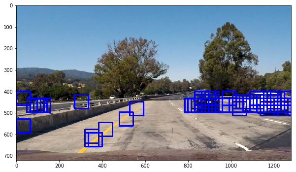

```python
ystart = 400
ystop = 656
scale = 1
#spatial_size = (32, 32)
#hist_bins=32

selected = 0
clf = trained_classifier['clf'][selected]
#X_scaler = trained_classifier['scaler'][selected]
color_space = features['cspace'][selected] # which is 'YUV'
orient = features['orient'][selected] # which is 11
hog_channel = hog_channels[3] # which is 'All'
pix_per_cell = 8
cell_per_block = 2

idx = 0
img = read_img(test_images[idx])

rectangles = find_cars(img, ystart, ystop, scale,
                    clf, orient, color_space,
                    pix_per_cell, cell_per_block,
                    None, None, False)

out_img = draw_boxes(img, rectangles)
plt.figure(figsize=(10,10))
plt.imshow(out_img)
```

### Combine Various Sliding Window Searches

```python
def sliding_window(img, ystart, ystop, scale,
                    clf, orient, color_space,
                    pix_per_cell, cell_per_block):

    all_rectangles = []
    ystart = 400
    ystop = 656
    scale = 1.0
    rectangles = find_cars(img, ystart, ystop, scale,
                        clf, orient, color_space,
                        pix_per_cell, cell_per_block,
                        None, None, False)
    all_rectangles.append(rectangles)

    ystart = 416
    ystop = 480
    scale = 1.0
    rectangles = find_cars(img, ystart, ystop, scale,
                        clf, orient, color_space,
                        pix_per_cell, cell_per_block,
                        None, None, False)
    all_rectangles.append(rectangles)

    ystart = 400
    ystop = 496
    scale = 1.5
    rectangles = find_cars(img, ystart, ystop, scale,
                        clf, orient, color_space,
                        pix_per_cell, cell_per_block,
                        None, None, False)
    all_rectangles.append(rectangles)

#     ystart = 432
#     ystop = 528
#     scale = 1.5
#     rectangles = find_cars(img, ystart, ystop, scale,
#                         clf, orient, color_space,
#                         pix_per_cell, cell_per_block,
#                         None, None, False)
#     all_rectangles.append(rectangles)

#     ystart = 400
#     ystop = 528
#     scale = 2.0
#     rectangles = find_cars(img, ystart, ystop, scale,
#                         clf, orient, color_space,
#                         pix_per_cell, cell_per_block,
#                         None, None, False)
#     all_rectangles.append(rectangles)

#     ystart = 432
#     ystop = 560
#     scale = 2.0
#     rectangles = find_cars(img, ystart, ystop, scale,
#                         clf, orient, color_space,
#                         pix_per_cell, cell_per_block,
#                         None, None, False)
#     all_rectangles.append(rectangles)

#     ystart = 400
#     ystop = 596
#     scale = 3.5
#     rectangles = find_cars(img, ystart, ystop, scale,
#                         clf, orient, color_space,
#                         pix_per_cell, cell_per_block,
#                         None, None, False)
#     all_rectangles.append(rectangles)

#     ystart = 464
#     ystop = 660
#     scale = 3.5
#     rectangles = find_cars(img, ystart, ystop, scale,
#                         clf, orient, color_space,
#                         pix_per_cell, cell_per_block,
#                         None, None, False)
#     all_rectangles.append(rectangles)

    all_rectangles = [item for sublist in all_rectangles for item in sublist]

    return all_rectangles
```

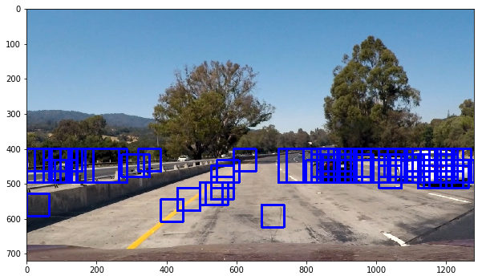

```python
idx = 0
img = read_img(test_images[idx])

selected = 1
clf = trained_classifier['clf'][selected]
color_space = features['cspace'][selected] # which is 'YUV'
orient = features['orient'][selected] # which is 11
hog_channel = hog_channels[3] # which is 'All'
pix_per_cell = 8
cell_per_block = 2

rectangles = sliding_window(img, ystart, ystop, scale,
                        clf, orient, color_space,
                        pix_per_cell, cell_per_block)
out_img = draw_boxes(img, rectangles)
plt.figure(figsize=(10,10))
plt.imshow(out_img)
```

### Heatmap

This method (duplicated from lesson material) produces a heat map based on rectangle locations (additive with overlap).

```python
def add_heat(heatmap, bbox_list):
    # Iterate through list of bboxes
    for box in bbox_list:
        # Add += 1 for all pixels inside each bbox
        # Assuming each "box" takes the form ((x1, y1), (x2, y2))
        heatmap[box[0][1]:box[1][1], box[0][0]:box[1][0]] += 1

    # Return updated heatmap
    return heatmap
```

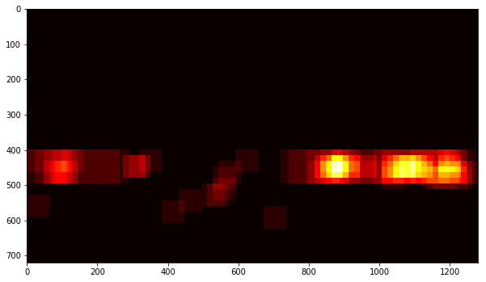

```python
heatmap_img = np.zeros_like(img[:,:,0])
heatmap_img = add_heat(heatmap_img, rectangles)
plt.figure(figsize=(10,10))
plt.imshow(heatmap_img, cmap='hot')
```

### Apply a Threshold to the Heatmap

```python
def apply_threshold(heatmap, threshold):
    # Zero out pixels below the threshold
    heatmap[heatmap <= threshold] = 0
    # Return thresholded map
    return heatmap
```

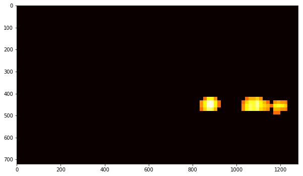

```python
heatmap_img = apply_threshold(heatmap_img, 9)
plt.figure(figsize=(10,10))
plt.imshow(heatmap_img, cmap='hot')
```

### Apply SciPy Labels to Heatmap

```
2 cars found
```

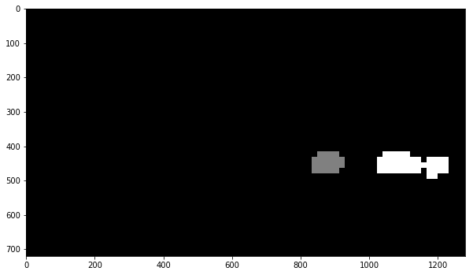

```python
labels = label(heatmap_img)
plt.figure(figsize=(10,10))
plt.imshow(labels[0], cmap='gray')
print(labels[1], 'cars found')
```

### Draw Bounding Boxes for Lables

```python
def draw_labeled_bboxes(img, labels):
    # Iterate through all detected cars
    rects = []
    for car_number in range(1, labels[1]+1):
        # Find pixels with each car_number label value
        nonzero = (labels[0] == car_number).nonzero()
        # Identify x and y values of those pixels
        nonzeroy = np.array(nonzero[0])
        nonzerox = np.array(nonzero[1])
        # Define a bounding box based on min/max x and y
        bbox = ((np.min(nonzerox), np.min(nonzeroy)), (np.max(nonzerox), np.max(nonzeroy)))
        rects.append(bbox)
        # Draw the box on the image
        cv2.rectangle(img, bbox[0], bbox[1], (0,0,255), 6)
    # Return the image and final rectangles
    return img, rects
```

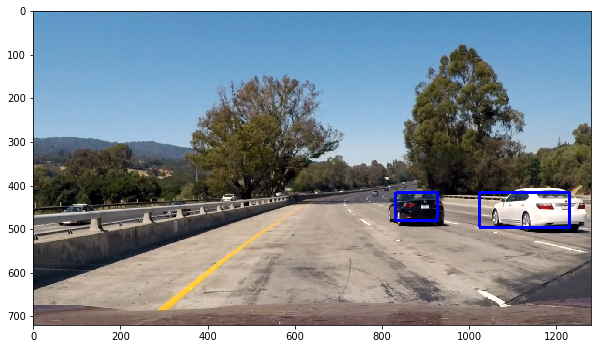

```python
# Draw bounding boxes on a copy of the image
draw_img, rect = draw_labeled_bboxes(np.copy(img), labels)
# Display the image
plt.figure(figsize=(10,10))
plt.imshow(draw_img)
```

```python
def process_frame(img):
    rectangles = sliding_window(img, ystart, ystop, scale,
                        clf, orient, color_space,
                        pix_per_cell, cell_per_block)

    heatmap_img = np.zeros_like(img[:,:,0])
    heatmap_img = add_heat(heatmap_img, rectangles)
    heatmap_img = apply_threshold(heatmap_img, 9)
    labels = label(heatmap_img)
    draw_img, rects = draw_labeled_bboxes(np.copy(img), labels)
    return draw_img
```

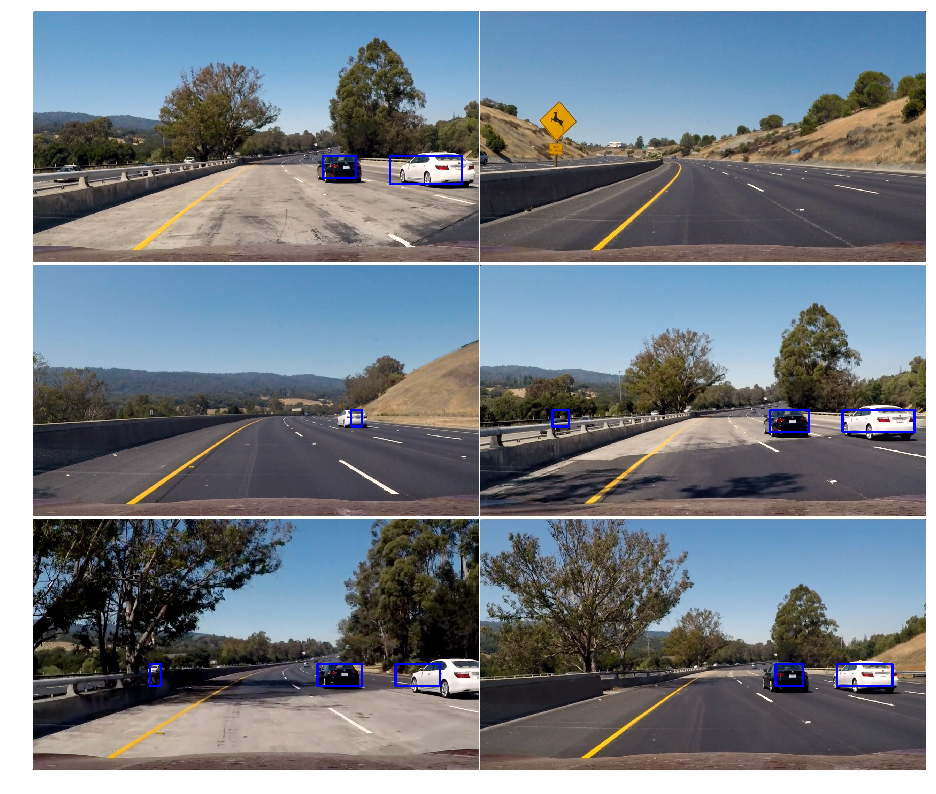

```python
test_images = glob.glob('./test_images/test*.jpg')

fig, axs = plt.subplots(3, 2, figsize=(16,14))
fig.subplots_adjust(hspace = .004, wspace=.002)
axs = axs.ravel()

for i, im in enumerate(test_images):
    img = read_img(test_images[i])
    axs[i].imshow(process_frame(img))
    axs[i].axis('off')
```

### Make the Video

This only processes a frame at a time without accounting for information from previous frames

```python
_output = 'output/project_video.mp4'
# white_output = 'test_videos_output/solidYellowLeft.mp4'
## To speed up the testing process you may want to try your pipeline on a shorter subclip of the video
## To do so add .subclip(start_second,end_second) to the end of the line below
## Where start_second and end_second are integer values representing the start and end of the subclip
## You may also uncomment the following line for a subclip of the first 5 seconds
##clip1 = VideoFileClip("test_videos/solidWhiteRight.mp4").subclip(0,5)
# clip1 = VideoFileClip("test_videos/project_video.mp4").subclip(19,25)
clip1 = VideoFileClip("project_video.mp4")
white_clip = clip1.fl_image(process_frame) #NOTE: this function expects color images!!
%time white_clip.write_videofile(_output, audio=False)
```

```
[MoviePy] >>>> Building video output/project_video.mp4
[MoviePy] Writing video output/project_video.mp4
```

```
[MoviePy] Done.
[MoviePy] >>>> Video ready: output/project_video.mp4

Wall time: 7min 58s
```